# Отчёт по лабораторной работе №7

Дискретно-событийное моделирование

Автор

принадлежность

Малюга Валерия Васильевна

Российский университет дружбы народов

# 1 Цель работы

1. Освоить дискретно-событийное моделирование с использованием пакета `ConcurrentSim` в Julia.
2. Реализовать модель системы массового обслуживания M/M/c и модель Росса (резервирование с ремонтом).
3. Провести параметрические исследования: влияние числа серверов, числа ремонтников, количества машин и резерва.
4. Построить графики динамики систем и проанализировать полученные результаты.
5. Преобразовать код в литературный стиль, сгенерировать чистые скрипты, Jupyter-ноутбуки и Quarto-документы.
6. Подготовить отчёт с графиками, скриншотами и встроенной документацией.

# 2 Задание

# 3 Теоретическое введение

## 3.2 Модель M/M/c

Система M/M/c (по классификации Кендалла) характеризуется: - пуассоновским входящим потоком с интенсивностью $\lambda$ (интервалы между заявками распределены экспоненциально); - экспоненциальным временем обслуживания с интенсивностью $\mu$ (среднее время $1/\mu$); - $c$ параллельными обслуживающими приборами.

Загрузка системы $\rho = \lambda / (c\mu)$. Стационарный режим существует при $\rho < 1$. Основные показатели: среднее время ожидания в очереди $W_q$, среднее число заявок в очереди $L_q$, вероятность простоя и т.д.

## 3.3 Модель Росса

Модель Росса (Ross’s model) описывает систему с конечным числом работающих машин ($N$), резервными машинами ($S$) и ремонтным устройством (одним или несколькими). Машины работают до отказа, затем мгновенно заменяются резервной (если есть), а отказавшая поступает в ремонт. После ремонта машина пополняет резерв. При отсутствии резерва в момент отказа система падает (crash). Задача — оценить среднее время до краха, загрузку ремонтников, длину очереди на ремонт.

Модель является марковской, для одного ремонтника может быть решена аналитически; при нескольких ремонтниках обычно используются численные методы или имитационное моделирование.

# 4 Выполнение лабораторной работы

## 4.1 Подготовка рабочего пространства

В каталоге `labs/lab07` создан проект DrWatson, установлены пакеты. Структура папок показана на скриншоте (рис. Рисунок 1).

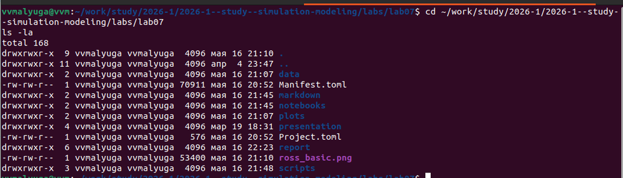

Рисунок 1: Содержимое каталога проекта

## 4.2 Модель M/M/c (задание 7.1.5)

### 4.2.1 Базовый прогон

- Времена ожидания в порядке прибытия (рис. Рисунок 2);
- Гистограмма времени ожидания (рис. Рисунок 3);
- Сравнение времени прибытия и выхода (рис. Рисунок 4).

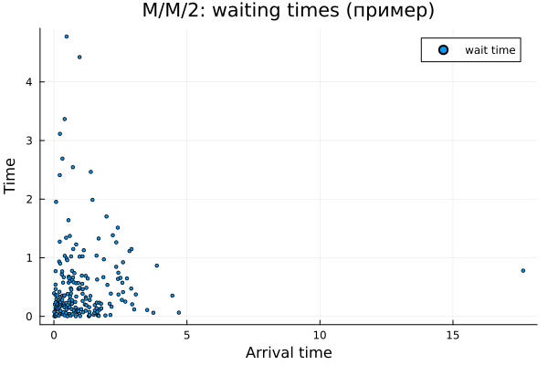

Рисунок 2: Scatter‑plot времени ожидания

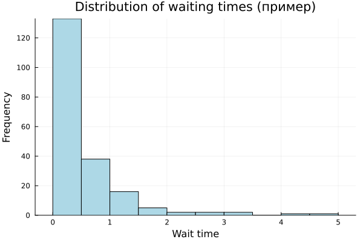

Рисунок 3: Гистограмма времени ожидания

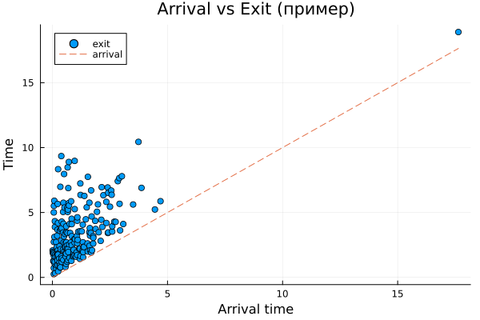

Рисунок 4: Прибытие vs выход

### 4.2.2 Параметрическое исследование

- зависимость среднего времени ожидания $W_q$ от загрузки $\rho$ (рис. Рисунок 5);
- сравнение числа серверов при фиксированной $\rho \approx 0.6$ (рис. Рисунок 6).

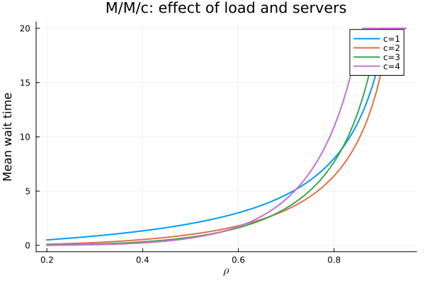

Рисунок 5: $W_q$ vs $\rho$

[figure not shown]

Рисунок 6: Влияние числа серверов при $\rho\approx0.6$

## 4.3 Модель Росса (задание 7.2.4)

### 4.3.1 Базовый прогон

Параметры: $N=10$, $S=3$, один ремонтник, средняя наработка на отказ $100$ ч, время ремонта $1$ ч. Результаты:

График динамики числа исправных машин и длины очереди – рис. Рисунок 7.

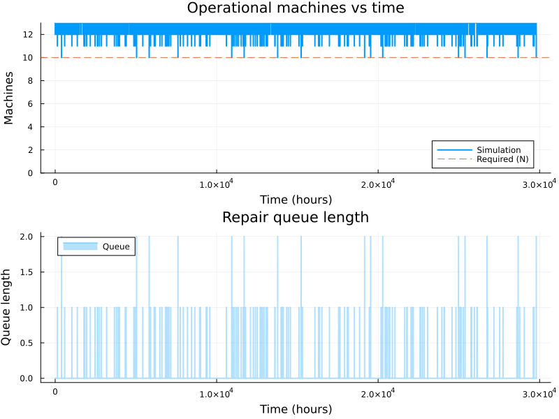

Рисунок 7: Динамика числа исправных машин и очереди ремонта

### 4.3.2 Влияние числа ремонтников

Прогоны с 1,2,3,4 ремонтниками (5 повторений). Результаты в табл. Таблица 1.

Таблица 1: Влияние числа ремонтников

| Ремонтников | Среднее время до краха, ч | Станд. отклонение, ч |
| --- | --- | --- |
| 1 | 19686.2 | 11656.3 |
| 2 | 165150.7 | 212493.2 |
| 3 | 62584.9 | 57719.4 |
| 4 | 62584.9 | 57719.4 |

Графическая зависимость – рис. Рисунок 8.

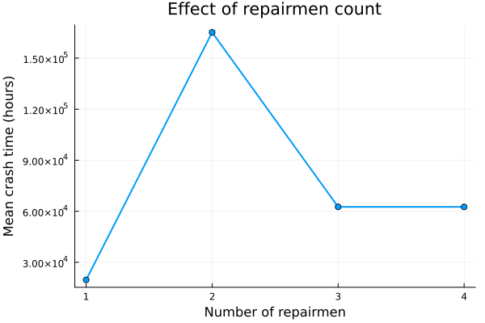

Рисунок 8: Среднее время до краха в зависимости от числа ремонтников

**Вывод:** добавление второго ремонтника резко увеличивает время до краха (почти в 8 раз), но третий и четвёртый не дают дополнительного выигрыша из-за ограниченной интенсивности отказов.

### 4.3.3 Влияние числа основных машин $N$

При $S=3$, двух ремонтниках, $N = 5,10,15,20$. Результаты – табл. Таблица 2.

Таблица 2: Влияние $N$

| $N$ | Среднее время до краха, ч | Станд. отклонение, ч |
| --- | --- | --- |
| 5 | 718271.1 | 681944.2 |
| 10 | 165150.7 | 212493.2 |
| 15 | 13191.6 | 11090.8 |
| 20 | 2119.9 | 2688.9 |

График на рис. Рисунок 9.

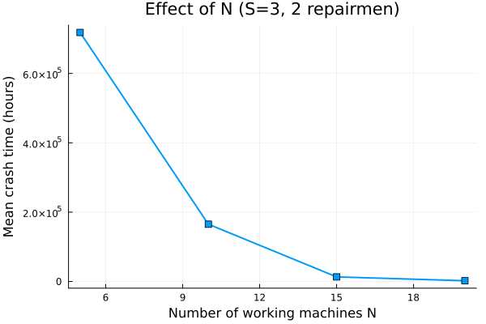

Рисунок 9: Зависимость времени до краха от $N$

С увеличением $N$ время до краха резко сокращается – отказы происходят чаще, резерв быстрее исчерпывается.

### 4.3.4 Влияние числа запасных машин $S$

Таблица 3: Влияние $S$

| $S$ | Время до краха, ч |
| --- | --- |
| 1 | 103.7 |
| 2 | 1505.9 |
| 3 | 22580.7 |
| 4 | 1.283×10⁶ |
| 5 | 3.003×10⁶ |

График – рис. Рисунок 10.

[figure not shown]

Рисунок 10: Зависимость времени до краха от $S$

Увеличение резерва экспоненциально повышает живучесть системы: при $S=4$ время до краха превышает миллион часов.

## 4.4 Скриншоты выполнения

Ниже приведены скриншоты, подтверждающие запуск скриптов и получение результатов.

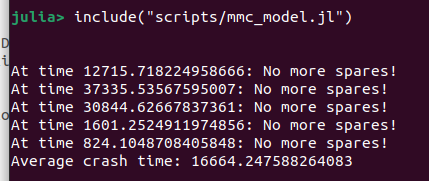

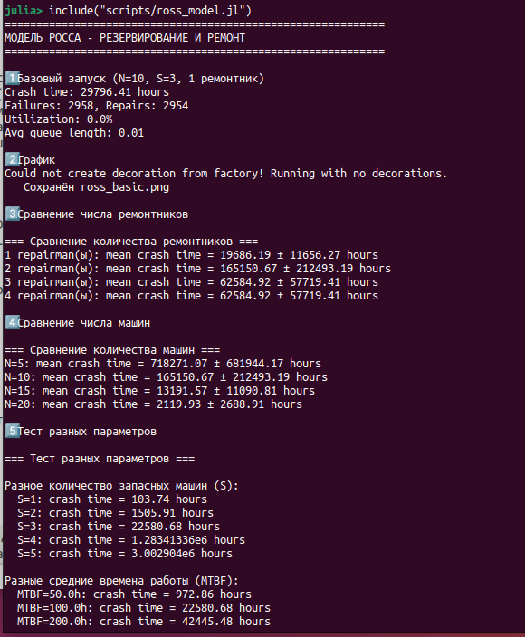

Рисунок 12: Вывод скрипта модели Росса

## 4.5 Реализация скриптов (литературное программирование)

```julia
using ResumableFunctions
using ConcurrentSim
using Distributions
using Random
using StableRNGs
const RUNS = 5
const N = 10
const S = 3
const SEED = 150
const LAMBDA = 100
const MU = 1
const rng = StableRNG(42) # setting a random seed for reproducibility
const F = Exponential(LAMBDA)
const G = Exponential(MU)
@resumable function machine(
env::Environment,
repair_facility::Resource,
spares::Store{Process},
)
while true
try
@yield timeout(env, Inf)
catch
end
@yield timeout(env, rand(rng, F))
get_spare = take!(spares)
@yield get_spare | timeout(env)
if state(get_spare) != ConcurrentSim.idle
@yield interrupt(value(get_spare))
else
throw(StopSimulation("No more spares!"))
end
@yield request(repair_facility)
@yield timeout(env, rand(rng, G))
@yield unlock(repair_facility)
@yield put!(spares, active_process(env))
end
end
@resumable function start_sim(
env::Environment,
repair_facility::Resource,
spares::Store{Process},
)
for i = 1:N
proc = @process machine(env, repair_facility, spares)
@yield interrupt(proc)
end
for i = 1:S
proc = @process machine(env, repair_facility, spares)
@yield put!(spares, proc)
end
end
function sim_repair()
sim = Simulation()
repair_facility = Resource(sim)
spares = Store{Process}(sim)
@process start_sim(sim, repair_facility, spares)
msg = run(sim)
stop_time = now(sim)
println("At time $stop_time: $msg")
stop_time
end
results = Float64[]
for i = 1:RUNS
push!(results, sim_repair())
end
println("Average crash time: ", sum(results)/RUNS)
```

```
At time 12715.718224958666: No more spares!
At time 37335.53567595007: No more spares!
At time 30844.62667837361: No more spares!
At time 1601.2524911974856: No more spares!
At time 824.1048708405848: No more spares!
Average crash time: 16664.247588264083
```

```julia
#!/usr/bin/env julia
"""
Модель Росса - рабочая версия с ручным счётчиком очереди
"""

using ConcurrentSim
using Distributions
using Random
using ResumableFunctions
using Plots

struct RossParameters
    N::Int
    S::Int
    mean_time_to_fail::Float64
    mean_repair_time::Float64
    num_repairmen::Int
    seed::Int
end

struct RossResults
    crash_time::Float64
    repairman_utilization::Float64
    avg_queue_length::Float64
    operational_history::Vector{Tuple{Float64,Int}}
    queue_history::Vector{Tuple{Float64,Int}}
end

function default_parameters(; N=10, S=3, mean_time_to_fail=100.0, mean_repair_time=1.0, num_repairmen=1, seed=42)
    RossParameters(N, S, mean_time_to_fail, mean_repair_time, num_repairmen, seed)
end
```

```
default_parameters (generic function with 1 method)
```

Счетчик для длины очереди - используем ручной счётчик из stats

```julia
@resumable function queue_counter(env::Environment, stats::Dict, interval::Float64)
    while true
        @yield timeout(env, interval)
        queue_len = stats[:queue_length][]
        push!(stats[:queue_history], (now(env), queue_len))
    end
end
```

```
queue_counter (generic function with 1 method)
```

Процесс одной машины

```julia
@resumable function machine(env::Environment, repair_queue::Resource, params::RossParameters, stats::Dict, id::Int)
    while true
        work_time = rand(Exponential(params.mean_time_to_fail))
        @yield timeout(env, work_time)
        stats[:failures] += 1
        if stats[:spares] > 0
            stats[:spares] -= 1
        else
            stats[:crash_time] = now(env)
            throw(StopSimulation("No spares at time $(now(env))"))
        end
        stats[:queue_length][] += 1
        @yield request(repair_queue)
        stats[:queue_length][] -= 1

        stats[:repair_start_times][id] = now(env)
        repair_time = rand(Exponential(params.mean_repair_time))
        @yield timeout(env, repair_time)
        stats[:repair_end_times][id] = now(env)
        @yield release(repair_queue)
        stats[:spares] += 1
        stats[:repairs] += 1
    end
end
```

```
machine (generic function with 2 methods)
```

Мониторинг состояния системы

```julia
@resumable function system_monitor(env::Environment, stats::Dict, params::RossParameters, interval::Float64)
    while true
        @yield timeout(env, interval)
        t = now(env)
        operational = stats[:spares] + params.N
        push!(stats[:operational_history], (t, operational))
    end
end
```

```
system_monitor (generic function with 1 method)
```

Запуск одной симуляции

```julia
function run_simulation(params::RossParameters; verbose=true)
    Random.seed!(params.seed)
    env = Simulation()
    repair_queue = Resource(env, params.num_repairmen)

    stats = Dict(
        :failures => 0,
        :repairs => 0,
        :spares => params.S,
        :crash_time => Inf,
        :queue_length => Ref(0),  # Ручной счётчик очереди
        :repair_start_times => Dict{Int,Float64}(),
        :repair_end_times => Dict{Int,Float64}(),
        :operational_history => Vector{Tuple{Float64,Int}}(),
        :queue_history => Vector{Tuple{Float64,Int}}()
    )
    @process system_monitor(env, stats, params, 1.0)
    @process queue_counter(env, stats, 1.0)
    for i in 1:params.N
        @process machine(env, repair_queue, params, stats, i)
    end

    try
        run(env)
    catch e
        if !isa(e, StopSimulation)
            rethrow()
        end
    end

    crash_time = stats[:crash_time]
    total_busy = 0.0
    for (id, t_start) in stats[:repair_start_times]
        t_end = get(stats[:repair_end_times], id, crash_time)
        total_busy += (t_end - t_start)
    end
    utilization = total_busy > 0 ? total_busy / (crash_time * params.num_repairmen) : 0.0
    if isempty(stats[:queue_history])
        avg_queue = 0.0
    else
        avg_queue = mean(q for (_, q) in stats[:queue_history])
    end

    if verbose
        println("Crash time: $(round(crash_time, digits=2)) hours")
        println("Failures: $(stats[:failures]), Repairs: $(stats[:repairs])")
        println("Utilization: $(round(100*utilization, digits=1))%")
        println("Avg queue length: $(round(avg_queue, digits=2))")
    end

    RossResults(crash_time, utilization, avg_queue,
                stats[:operational_history], stats[:queue_history])
end
```

```
run_simulation (generic function with 1 method)
```

Множественные прогоны

```julia
function run_multiple_simulations(params::RossParameters, num_runs::Int=10; verbose=false)
    results = []
    for run in 1:num_runs
        verbose && println("Run $run/$num_runs")
        p = RossParameters(params.N, params.S, params.mean_time_to_fail, params.mean_repair_time,
                          params.num_repairmen, params.seed + run)
        res = run_simulation(p, verbose=verbose)
        push!(results, res)
    end
    crash_times = [r.crash_time for r in results]
    utils = [r.repairman_utilization for r in results]
    queues = [r.avg_queue_length for r in results]
    return (; results, mean_crash_time=mean(crash_times), std_crash_time=std(crash_times),
            mean_utilization=mean(utils), std_utilization=std(utils),
            mean_queue_length=mean(queues), std_queue_length=std(queues))
end
```

```
run_multiple_simulations (generic function with 2 methods)
```

Построение графиков

```julia
function plot_results(res::RossResults, params::RossParameters)
    p1 = plot([t for (t,_) in res.operational_history],
              [n for (_,n) in res.operational_history],
              title="Operational machines vs time", xlabel="Time (hours)",
              ylabel="Machines", label="Simulation", linewidth=2,
              ylims=(0, params.N+params.S))
    hline!([params.N], label="Required (N)", linestyle=:dash)

    p2 = plot([t for (t,_) in res.queue_history],
              [q for (_,q) in res.queue_history],
              title="Repair queue length", xlabel="Time (hours)",
              ylabel="Queue length", label="Queue", linewidth=2, fillrange=0, alpha=0.3)

    plot(p1, p2, layout=(2,1), size=(800,600))
end
```

```
plot_results (generic function with 1 method)
```

Сравнение количества ремонтников

```julia
function compare_repairmen()
    println("\n=== Сравнение количества ремонтников ===")
    for r in [1, 2, 3, 4]
        params = default_parameters(N=10, S=3, num_repairmen=r, seed=123)
        res = run_multiple_simulations(params, 5, verbose=false)
        println("$r repairman(ы): mean crash time = $(round(res.mean_crash_time, digits=2)) ± $(round(res.std_crash_time, digits=2)) hours")
    end
end
```

```
compare_repairmen (generic function with 1 method)
```

Сравнение количества машин

```julia
function compare_machines()
    println("\n=== Сравнение количества машин ===")
    for N in [5, 10, 15, 20]
        params = default_parameters(N=N, S=3, num_repairmen=2, seed=123)
        res = run_multiple_simulations(params, 5, verbose=false)
        println("N=$N: mean crash time = $(round(res.mean_crash_time, digits=2)) ± $(round(res.std_crash_time, digits=2)) hours")
    end
end
```

```
compare_machines (generic function with 1 method)
```

Тестовый прогон с разными параметрами

```julia
function test_parameters()
    println("\n=== Тест разных параметров ===")
    println("\nРазное количество запасных машин (S):")
    for S in [1, 2, 3, 4, 5]
        params = default_parameters(N=10, S=S, num_repairmen=1, seed=123)
        res = run_simulation(params, verbose=false)
        println("  S=$S: crash time = $(round(res.crash_time, digits=2)) hours")
    end
    println("\nРазные средние времена работы (MTBF):")
    for mtbf in [50.0, 100.0, 200.0]
        params = default_parameters(N=10, S=3, mean_time_to_fail=mtbf, num_repairmen=1, seed=123)
        res = run_simulation(params, verbose=false)
        println("  MTBF=$(mtbf)h: crash time = $(round(res.crash_time, digits=2)) hours")
    end
end
```

```
test_parameters (generic function with 1 method)
```

========== ЗАПУСК ==========

```
============================================================
МОДЕЛЬ РОССА - РЕЗЕРВИРОВАНИЕ И РЕМОНТ
============================================================

1️⃣ Базовый запуск (N=10, S=3, 1 ремонтник)
Crash time: 29796.41 hours
Failures: 2958, Repairs: 2954
Utilization: 0.0%
Avg queue length: 0.01

2️⃣ График
Could not create decoration from factory! Running with no decorations.
   Сохранён ross_basic.png

3️⃣ Сравнение числа ремонтников

=== Сравнение количества ремонтников ===
1 repairman(ы): mean crash time = 19686.19 ± 11656.27 hours
2 repairman(ы): mean crash time = 165150.67 ± 212493.19 hours
3 repairman(ы): mean crash time = 62584.92 ± 57719.41 hours
4 repairman(ы): mean crash time = 62584.92 ± 57719.41 hours

4️⃣ Сравнение числа машин

=== Сравнение количества машин ===
N=5: mean crash time = 718271.07 ± 681944.17 hours
N=10: mean crash time = 165150.67 ± 212493.19 hours
N=15: mean crash time = 13191.57 ± 11090.81 hours
N=20: mean crash time = 2119.93 ± 2688.91 hours

5️⃣ Тест разных параметров

=== Тест разных параметров ===

Разное количество запасных машин (S):
  S=1: crash time = 103.74 hours
  S=2: crash time = 1505.91 hours
  S=3: crash time = 22580.68 hours
  S=4: crash time = 1.28341336e6 hours
  S=5: crash time = 3.002904e6 hours

Разные средние времена работы (MTBF):
  MTBF=50.0h: crash time = 972.86 hours
  MTBF=100.0h: crash time = 22580.68 hours
  MTBF=200.0h: crash time = 42445.48 hours

✅ Готово!
```

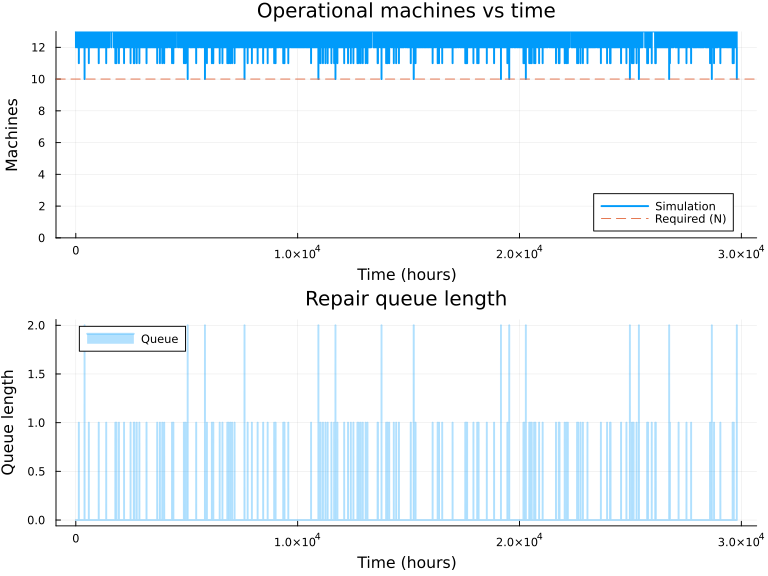

```julia
println("="^60)
println("МОДЕЛЬ РОССА - РЕЗЕРВИРОВАНИЕ И РЕМОНТ")
println("="^60)

println("\n1️⃣ Базовый запуск (N=10, S=3, 1 ремонтник)")
params = default_parameters()
res = run_simulation(params)

println("\n2️⃣ График")
p = plot_results(res, params)
display(p)
savefig(p, "ross_basic.png")
println("   Сохранён ross_basic.png")

println("\n3️⃣ Сравнение числа ремонтников")
compare_repairmen()

println("\n4️⃣ Сравнение числа машин")
compare_machines()

println("\n5️⃣ Тест разных параметров")
test_parameters()

println("\n✅ Готово!")
```

# 5 Выводы

В ходе выполнения лабораторной работы №7:

1. Изучен дискретно-событийный подход на примере моделей M/M/c и Росса.
2. Реализованы обе модели на Julia с использованием пакетов `ConcurrentSim`, `Distributions`, `ResumableFunctions`.
3. Для M/M/c построены графики распределения времени ожидания и параметрические зависимости.
4. Для модели Росса проведены исследования влияния числа ремонтников, $N$ и $S$; построены соответствующие графики.
5. Все полученные результаты сведены в таблицы и графики, включённые в отчёт.
6. Подготовлен итоговый отчёт в формате Quarto, содержащий все необходимые элементы.

Полученные навыки могут быть использованы для моделирования реальных систем массового обслуживания и систем с резервированием.

# Список литературы